# *“Análisis de futbolistas Temporada 23/24”*

Daniel Villar Rodríguez

13 de Agosto de 2024

En este proyecto se pretende realizar un análisis integral de datos de jugadores de fútbol que jugaron durante esta última temporada 23/24 en diversas competiciones. Los datos se han obtenido del portal web TransferMarkt con un proceso de web scraping el 02/06/24.

# CONEXION A LA BASE DE DATOS SQL

A continuación, se explica el proceso de conexión a una base de datos en SQL Server desde la interfaz de RStudio.

```r
# Cargamos las librerias necesarias:

library(dplyr)
library(odbc)

# Establecemos la función de conexión:

connect_to_db <- function(driver, server, database) {
  connection_string <- paste0("Driver={", driver, "};Server=", server,
                              ";Database=", database, ";Trusted_Connection=yes;
                              ")
  dbConnect(odbc::odbc(), .connection_string = connection_string)
}

# Establecemos la conexión con SQL Server:

conn <- connect_to_db("ODBC Driver 17 for SQL Server", "LAPTOP-P7645H6F",
                      "TransferMarkt")

# Ejecutamos una consulta en lenguaje T-SQL para extraer y transformar los
# datos objetos del análisis:

query <- "
WITH T1 AS -- SUSTITUCION DE DATOS FALTANTES EN VARIABLES CATEGORICAS 'pais_nacimiento' y 'pie_bueno'
  (
    SELECT
      ROW_NUMBER () OVER (ORDER BY T1.player_id) AS nro_filas,
      T1.player_id,
      CASE WHEN T1.country_of_birth IS NULL THEN 'N/A' ELSE T1.country_of_birth END AS pais_nacimiento,
      DATEDIFF (YEAR, T1.date_of_birth, GETDATE()) AS edad_actual,
      T1.last_season,
      T1.position,
      CASE WHEN T1.foot IS NULL THEN 'N/A' ELSE T1.foot END AS pie_bueno,
      T1.height_in_cm AS altura,
      T1.market_value_in_eur AS valor_mercado,
      SUM (T2.assists) AS asistencias,
      SUM (T2.goals) AS goles,
      SUM (T2.minutes_played) AS minutos_jugados,
      SUM (T2.yellow_cards) AS tarjetas_amarillas,
      SUM (T2.red_cards) AS tarjetas_rojas
    FROM
      dbo.[players.dim] T1
      INNER JOIN dbo.appearances_fct T2
      ON T1.player_id = T2.player_id
    WHERE
      T1.last_season = 2023
      GROUP BY
      T1.player_id,
      T1.country_of_birth,
      DATEDIFF (YEAR, T1.date_of_birth, GETDATE()),
      T1.last_season,
      T1.position,
      T1.foot,
      T1.height_in_cm,
      T1.market_value_in_eur
  ),
    tabla2 AS -- IMPUTACION DE DATOS FALTANTES EN VARIABLE NUMERICA 'valor_mercado'; PARA ELLO SE CREA
              -- UNA VISTA CON LOS VALORES DE MERCADO DE JUGADORES VALORADOS Y SE ESTIMA UNA MEDIA DE
              -- VALOR PARA LOS DATOS FALTANTES CATEGORIZADA POR EDAD, POSICION Y VALOR_MERCADO/MINUTO
  (
SELECT
  T1.player_id,
  T1.pais_nacimiento,
  T1.edad_actual,
  T1.position,
  T1.pie_bueno,
  T1.altura,
  CASE WHEN T1.valor_mercado IS NULL THEN T2.valor_mercado ELSE T1.valor_mercado END AS valor_mercado_rev,
  T1.asistencias,
  T1.goles,
  T1.minutos_jugados,
  T1.tarjetas_amarillas,
  T1.tarjetas_rojas
FROM
  T1
  LEFT JOIN dbo.valoracionjugadoresNEW T2
  ON T1.player_id = T2.player_id
  )
  , tabla3 AS-- IMPUTACION DE DATOS FALTANTES EN VARIABLE NUMERICA 'altura' CON LA MEDIA SIN DATOS FALTANTES
  (
SELECT
  player_id,
  pais_nacimiento,
  edad_actual,
  position,
  pie_bueno,
  CASE WHEN altura IS NULL THEN 182 ELSE altura END AS Altura,
  valor_mercado_rev AS Valor_mercado,
  asistencias,
  goles,
  minutos_jugados,
  tarjetas_amarillas,
  tarjetas_rojas,
  CASE WHEN position = 'Missing' THEN 'Attack' ELSE position END AS position_rev
FROM
  tabla2
  )
SELECT
  player_id,
  pais_nacimiento,
  edad_actual,
  position_rev AS position,
  pie_bueno,
  Altura,
  Valor_mercado,
  asistencias,
  goles,
  minutos_jugados,
  tarjetas_amarillas,
  tarjetas_rojas
FROM tabla3
"

# Finalmente, obtenemos los resultados y lo guardamos en un dataframe que
# usaremos para los análisis con R:

df <- dbGetQuery(conn, query)
```

Previamente al proceso conexión con la consulta a la base de datos realizamos las transformaciones y limpieza de datos faltantes y realizamos la imputación de datos faltantes en las variables categoricas por el valor N/A y en las variables numéricas ‘altura’ y ‘valor_mercado’ por su media y un cálculo de valor de mercado con respecto a los datos promedios de los jugadores valorados como la edad, posición y valor de mercado por minuto jugado, respectivamente.

# VISUALIZACION DE LOS DATOS OBTENIDOS EN LA CONSULTA

A continuación, se muestra el resultado de la consulta SQL.

| player_id | pais_nacimiento | edad_actual | position | pie_bueno | Altura | Valor_mercado | asistencias | goles | minutos_jugados | tarjetas_amarillas | tarjetas_rojas |
| --- | --- | --- | --- | --- | --- | --- | --- | --- | --- | --- | --- |
| 171679 | Ireland | 32 | Defender | right | 185 | 3000000 | 24 | 21 | 13584 | 15 | 0 |
| 181410 | Slovenia | 30 | Defender | left | 185 | 1200000 | 9 | 10 | 8759 | 21 | 0 |
| 450050 | France | 26 | Midfield | right | 172 | 15000000 | 17 | 9 | 10022 | 17 | 1 |
| 479999 | England | 26 | Midfield | right | 178 | 55000000 | 17 | 26 | 8522 | 11 | 0 |
| 800976 | Cote d'Ivoire | 22 | Defender | right | 185 | 6000000 | 2 | 4 | 5694 | 15 | 1 |
| 193998 | Croatia | 30 | Midfield | right | 176 | 300000 | 1 | 0 | 1118 | 4 | 0 |
| 371814 | England | 27 | Defender | right | 190 | 3500000 | 1 | 1 | 2769 | 8 | 0 |
| 821535 | Ukraine | 24 | Attack | right | 181 | 100000 | 1 | 9 | 2816 | 5 | 0 |
| 148485 | Russia | 32 | Defender | right | 181 | 800000 | 17 | 3 | 14320 | 28 | 0 |
| 537854 | Ukraine | 24 | Midfield | left | 182 | 9000000 | 15 | 25 | 7415 | 13 | 2 |

[output cut: 6276 more lines]

# VISTA GENERAL DEL DATASET

Vemos una vista general y realizamos un análisis descriptivo básico del conjunto de datos.

```
## 'data.frame':    6286 obs. of  12 variables:
##  $ player_id         : int  171679 181410 450050 479999 800976 193998 371814 821535 148485 537854 ...
##  $ pais_nacimiento   : chr  "Ireland" "Slovenia" "France" "England" ...
##  $ edad_actual       : int  32 30 26 26 22 30 27 24 32 24 ...
##  $ position          : chr  "Defender" "Defender" "Midfield" "Midfield" ...
##  $ pie_bueno         : chr  "right" "left" "right" "right" ...
##  $ Altura            : int  185 185 172 178 185 176 190 181 181 182 ...
##  $ Valor_mercado     : int  3000000 1200000 15000000 55000000 6000000 300000 3500000 100000 800000 9000000 ...
##  $ asistencias       : int  24 9 17 17 2 1 1 1 17 15 ...
##  $ goles             : int  21 10 9 26 4 0 1 9 3 25 ...
##  $ minutos_jugados   : int  13584 8759 10022 8522 5694 1118 2769 2816 14320 7415 ...
##  $ tarjetas_amarillas: int  15 21 17 11 15 4 8 5 28 13 ...
##  $ tarjetas_rojas    : int  0 0 1 0 1 0 0 0 0 2 ...
```

Data summary

| Name | df |
| --- | --- |
| Number of rows | 6286 |
| Number of columns | 12 |
| _______________________ |  |
| Column type frequency: |  |
| character | 3 |
| numeric | 9 |
| ________________________ |  |
| Group variables | None |

**Variable type: character**

| skim_variable | n_missing | complete_rate | min | max | empty | n_unique | whitespace |
| --- | --- | --- | --- | --- | --- | --- | --- |
| pais_nacimiento | 0 | 1 | 3 | 21 | 0 | 140 | 0 |
| position | 0 | 1 | 6 | 10 | 0 | 4 | 0 |
| pie_bueno | 0 | 1 | 3 | 5 | 0 | 4 | 0 |

**Variable type: numeric**

| skim_variable | n_missing | complete_rate | mean | sd | p0 | p25 | p50 | p75 | p100 | hist |
| --- | --- | --- | --- | --- | --- | --- | --- | --- | --- | --- |
| player_id | 0 | 1 | 423698.37 | 252552.42 | 3333 | 226141.25 | 388361 | 593275.50 | 1240467 | ▆▇▆▂▁ |
| edad_actual | 0 | 1 | 26.61 | 4.60 | 16 | 23.00 | 26 | 30.00 | 43 | ▃▇▇▂▁ |
| Altura | 0 | 1 | 182.68 | 6.79 | 160 | 178.00 | 183 | 188.00 | 206 | ▁▅▇▅▁ |
| Valor_mercado | 0 | 1 | 5771750.92 | 12396360.42 | 2591 | 450000.00 | 1500000 | 5000000.00 | 180000000 | ▇▁▁▁▁ |
| asistencias | 0 | 1 | 9.03 | 15.77 | 0 | 0.00 | 3 | 11.00 | 210 | ▇▁▁▁▁ |
| goles | 0 | 1 | 11.38 | 23.59 | 0 | 0.00 | 3 | 12.00 | 467 | ▇▁▁▁▁ |
| minutos_jugados | 0 | 1 | 7730.16 | 8184.44 | 1 | 1486.00 | 4872 | 11500.75 | 47788 | ▇▂▁▁▁ |
| tarjetas_amarillas | 0 | 1 | 15.56 | 18.44 | 0 | 2.25 | 9 | 22.00 | 147 | ▇▁▁▁▁ |
| tarjetas_rojas | 0 | 1 | 0.38 | 0.76 | 0 | 0.00 | 0 | 1.00 | 7 | ▇▁▁▁▁ |

Podemos apreciar que no existen valores faltantes ya que realizamos el proceso de transformación y limpieza de datos en la consulta SQL desde SSMS.

Vamos a agregar una nueva variable con el total de tarjetas por cada jugador:

```r
attach(df) # uso de la función attach para reducir el código de escritura
library(dplyr)
df <- df %>% mutate(total_tarjetas = tarjetas_amarillas + tarjetas_rojas)
```

Comprobamos que la nueva variable es correcta:

```r
df %>%
  select(player_id, tarjetas_amarillas, tarjetas_rojas, total_tarjetas)
```

| player_id | tarjetas_amarillas | tarjetas_rojas | total_tarjetas |
| --- | --- | --- | --- |
| 171679 | 15 | 0 | 15 |
| 181410 | 21 | 0 | 21 |
| 450050 | 17 | 1 | 18 |
| 479999 | 11 | 0 | 11 |
| 800976 | 15 | 1 | 16 |
| 193998 | 4 | 0 | 4 |
| 371814 | 8 | 0 | 8 |
| 821535 | 5 | 0 | 5 |
| 148485 | 28 | 0 | 28 |
| 537854 | 13 | 2 | 15 |

[output cut: 6276 more lines]

# ANALISIS DE VARIABLES

## ANALISIS DE UNA VARIABLE

### Tablas de frecuencias

```r
# Llamamos al comando attach para reducir el código de escritura:
```

Realizamos una tabla de frecuencias tanto absoluta como relativa de la variable categórica ‘position’.

```
## position
##     Attack   Defender Goalkeeper   Midfield
##       1704       2141        632       1809
```

```
## position
##     Attack   Defender Goalkeeper   Midfield
##  0.2710786  0.3405982  0.1005409  0.2877824
```

### Gráfico de barras (ranking)

Ahora se procede a visualizar los datos obtenidos en un gráfico de barras, a modo de rankear los valores que se repiten con más frecuencia.

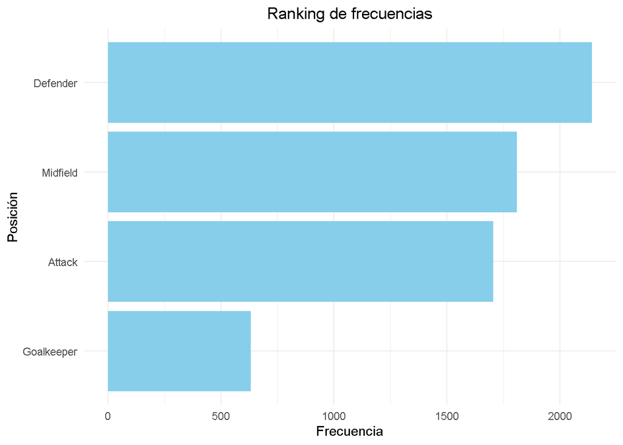

```r
library(ggplot2)


freq_table <- as.data.frame(table(position))

freq_table <- freq_table[order(-freq_table$Freq), ]

ggplot(freq_table, aes(x = reorder(position, Freq), y = Freq)) +
  geom_bar(stat = "identity", fill = "skyblue") +
  coord_flip() +
  labs(title = 'Ranking de frecuencias',
       x = 'Posición',
       y = 'Frecuencia') +
  theme_minimal() +
  theme(plot.title = element_text(hjust = 0.5))
```

Para refutar la observación en la tabla de frecuencias, se realiza la prueba de chi-cuadrado:

H0 (hipótesis nula): las frecuencias observadas se ajustan a las frecuencias esperadas.

H1 (hipótesis alternativa): las frecuencias observadas NO se ajustan a las frecuencias esperadas.

```r
freq_observada <- table(position)


n <- length(position)
posiciones <- names(freq_observada)
frecuencias_esperadas <- rep(n / length(posiciones), length(posiciones))


resultado_prueba <- chisq.test(freq_observada, p = frecuencias_esperadas / sum(frecuencias_esperadas))


print(resultado_prueba)
```

```
##
##  Chi-squared test for given probabilities
##
## data:  freq_observada
## X-squared = 815.11, df = 3, p-value < 2.2e-16
```

Dado que el valor p es extremadamente bajo, **se rechaza la hipótesis nula.** Esto significa que hay una diferencia significativa entre las frecuencias observadas y las esperadas bajo la hipótesis nula de una distribución uniforme y se refuta lo observado en el gráfico, es decir, que estadísticamente se demuestra que **no hay una distribución uniforme en los datos**.

También obtenemos el top 5 de paises que más jugadores tienen en las diferentes competiciones, con un gradiente de color azul:

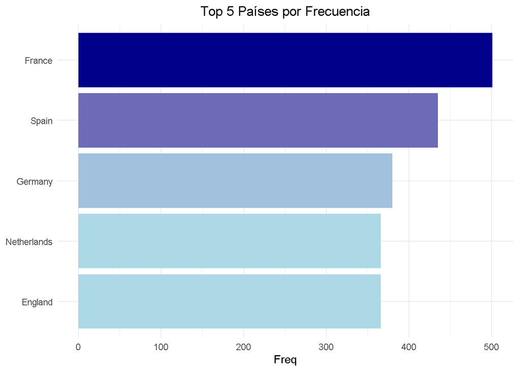

```r
library(ggplot2)

freq_table <- as.data.frame(table(df$pais_nacimiento))

names(freq_table) <- c("pais_nacimiento", "Freq")

freq_table <- freq_table[order(-freq_table$Freq), ]

top5_freq_table <- head(freq_table, 5)

top5_freq_table$pais_nacimiento <- factor(top5_freq_table$pais_nacimiento,
                                           levels = top5_freq_table$pais_nacimiento[order(top5_freq_table$Freq)])

ggplot(top5_freq_table, aes(x = pais_nacimiento, y = Freq, fill = Freq)) +
  geom_bar(stat = "identity") +
  scale_fill_gradient(low = "lightblue", high = "darkblue") +
  coord_flip() +
  labs(title = 'Top 5 Países por Frecuencia',
       x = 'País') +
  theme_minimal() +
  theme(
    plot.title = element_text(hjust = 0.5),
    legend.position = "none",
    axis.title.y = element_blank()
  )
```

### Histogramas y gráficos de normalidad (QQ plot)

A continuación, veremos una histograma con la variable cuantitativa ‘edad_actual’ y analizaremos la distribución de los datos.

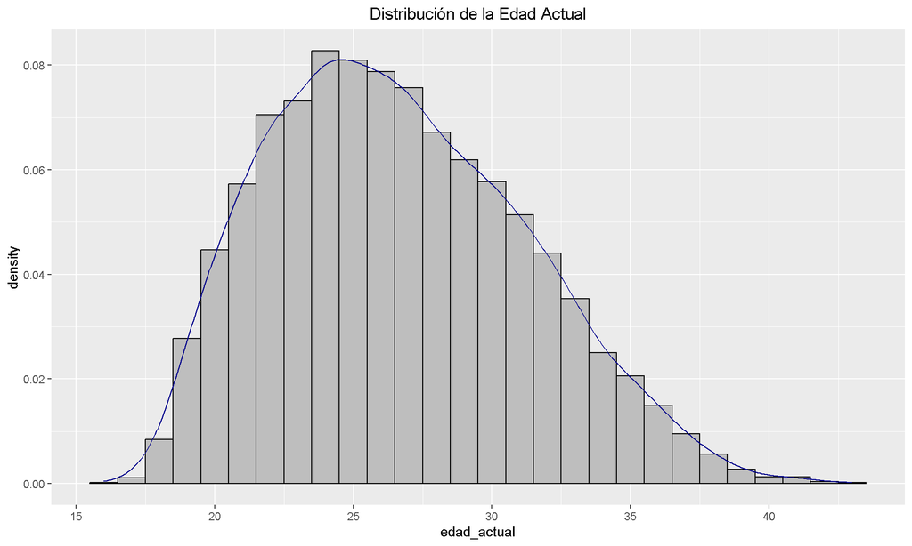

Data summary

| Name | edad_actual |
| --- | --- |
| Number of rows | 6286 |
| Number of columns | 1 |
| _______________________ |  |
| Column type frequency: |  |
| numeric | 1 |
| ________________________ |  |
| Group variables | None |

```r
library(ggplot2)
ggplot(df) +
  aes(x = edad_actual, y = ..density..) +
  geom_histogram(binwidth = 1, fill = "grey", color = "black") +
  geom_density(color = "darkblue") +
  ggtitle("Distribución de la Edad Actual") +
  theme(plot.title = element_text(color = "black", hjust = 0.5))
```

**Variable type: numeric**

| skim_variable | n_missing | complete_rate | mean | sd | p0 | p25 | p50 | p75 | p100 | hist |
| --- | --- | --- | --- | --- | --- | --- | --- | --- | --- | --- |
| data | 0 | 1 | 26.61 | 4.6 | 16 | 23 | 26 | 30 | 43 | ▃▇▇▂▁ |

```
## [1] "Asimetría = 0.385246899330668"
```

Visualmente observamos que los datos presentan una distribución aproximadamente normal, con una ligera asimetría a la derecha (cola larga hacia la derecha), lo cual indica que ligeramente existe más concentración de edades a la izquierda de la media de los datos, es decir, que es más frecuente los jugadores con 26,62 años o menos en el conjunto de datos analizados.

Para refutar la normalidad de los datos, vamos a realizar la prueba de Kolmogorov-Smirnov para altos volumenes de observaciones.

```r
ks_test <- ks.test(edad_actual, "pnorm", mean = mean(edad_actual), sd = sd(edad_actual))
print(ks_test)
```

```
##
##  Asymptotic one-sample Kolmogorov-Smirnov test
##
## data:  edad_actual
## D = 0.083251, p-value < 2.2e-16
## alternative hypothesis: two-sided
```

El resultado de la prueba arroja un p-valor muy bajo, lo que indica que los valores **NO** siguen una distribución normal; seguidamente procedemos a visualizar la variable con un gráfico Q-Qplot para visualizar la NO normalidad.

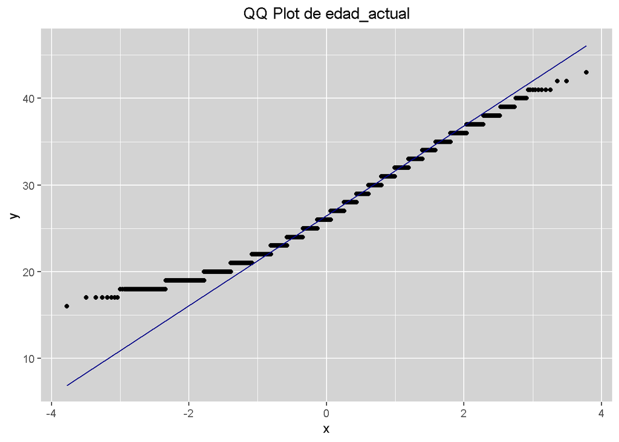

```r
ggplot(df, aes(sample = edad_actual)) +
  stat_qq(distribution = qnorm) +
  stat_qq_line(distribution = qnorm, color = "darkblue") +
  ggtitle("QQ Plot de edad_actual") +
  theme(panel.background = element_rect(fill = "lightgrey"),
        plot.title = element_text(color = "black", hjust = 0.5))
```

Vamos a proceder a transformar los datos para un mejor ajuste con la distribución normal; para ello, realizamos una trasformación logarítmica y a continuación visualizaremos el resultado obtenido en un gráfico Q-Qplot y en un histograma.

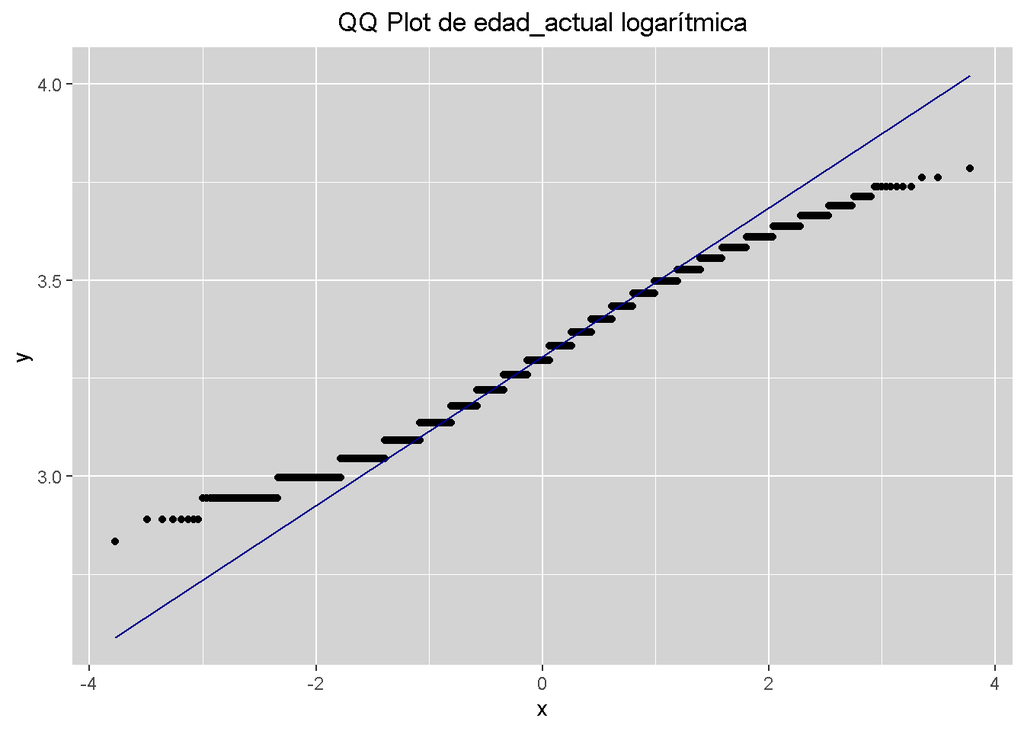

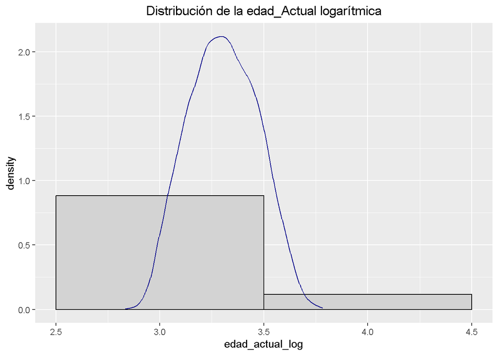

Table: Data summary

| Name | edad_actual_log |
| --- | --- |
| Number of rows | 6286 |
| Number of columns | 1 |
| _______________________ |  |
| Column type frequency: |  |
| numeric | 1 |
| ________________________ |  |
| Group variables | None |

**Variable type: numeric**

| skim_variable | n_missing | complete_rate | mean | sd | p0 | p25 | p50 | p75 | p100 | hist |
| --- | --- | --- | --- | --- | --- | --- | --- | --- | --- | --- |
| data | 0 | 1 | 3.3 | 0.17 | 2.83 | 3.18 | 3.3 | 3.43 | 3.78 | ▁▅▇▅▁ |

```
## [1] "Asimetría = 0.0457196502730759"
```

**Con esta transformación, podemos realizar pruebas de modelización de Machine Learning y comparar los resultados con la variable antes de la transformación para ver cual tiene mejor rendimiento.**

Ahora realizamos una visualización de histograma con las alturas de los jugadores.

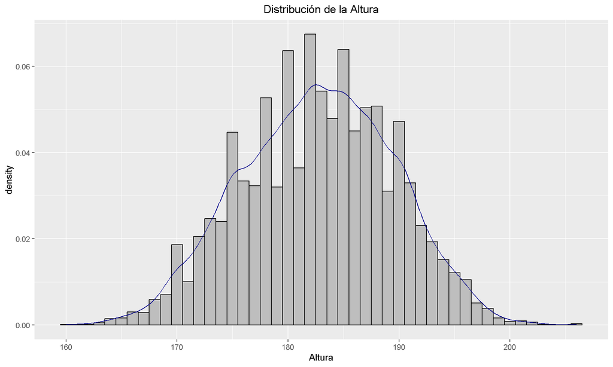

Data summary

| Name | Altura |
| --- | --- |
| Number of rows | 6286 |
| Number of columns | 1 |
| _______________________ |  |
| Column type frequency: |  |
| numeric | 1 |
| ________________________ |  |
| Group variables | None |

```r
ggplot(df) +
  aes(x = Altura, y = ..density..) +
  geom_histogram(binwidth = 1, fill = "grey", color = "black") +
  geom_density(color = "darkblue") +
  ggtitle("Distribución de la Altura") +
  theme(plot.title = element_text(color = "black", hjust = 0.5))
```

**Variable type: numeric**

| skim_variable | n_missing | complete_rate | mean | sd | p0 | p25 | p50 | p75 | p100 | hist |
| --- | --- | --- | --- | --- | --- | --- | --- | --- | --- | --- |
| data | 0 | 1 | 182.68 | 6.79 | 160 | 178 | 183 | 188 | 206 | ▁▅▇▅▁ |

```
## [1] "Asimetría = -0.0830200821818184"
```

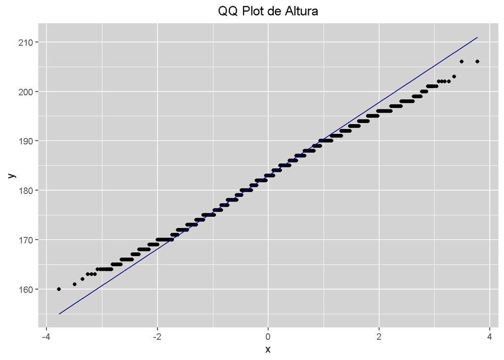

```r
ggplot(df, aes(sample = Altura)) +
  stat_qq(distribution = qnorm) +
  stat_qq_line(distribution = qnorm, color = "darkblue") +
  ggtitle("QQ Plot de Altura") +
  theme(panel.background = element_rect(fill = "lightgrey"),
        plot.title = element_text(color = "black", hjust = 0.5))
```

## ANALISIS DE DOS VARIABLES

### Tabla de doble entrada

Realizamos una tabla de doble entrada para mostrar las frecuencias de alturas de los jugadores con relación a la posición que ocupa en el terreno de juego.

```
##       position
## Altura Attack Defender Goalkeeper Midfield
##    160      1        0          0        0
##    161      1        0          0        0
##    162      0        0          0        1
##    163      1        2          0        0
##    164      5        0          0        4
##    165      6        0          0        4
##    166     11        2          0        6
##    167     10        2          0        6
##    168     17        5          0       15
##    169     17        6          0       21
##    170     47       25          0       45
##    171     26       16          0       21
##    172     55       26          0       48
```

[output cut: 32 more lines]

### Mapas de calor

Esta misma tabla la vamos a visualizar como un mapa de calor, donde se aplica un degradado de color azul, representándose con colores más intensos los valores con mayor frecuencia y es mucho más fácil de ver a simple vista que con una tabla de frecuencias normal.

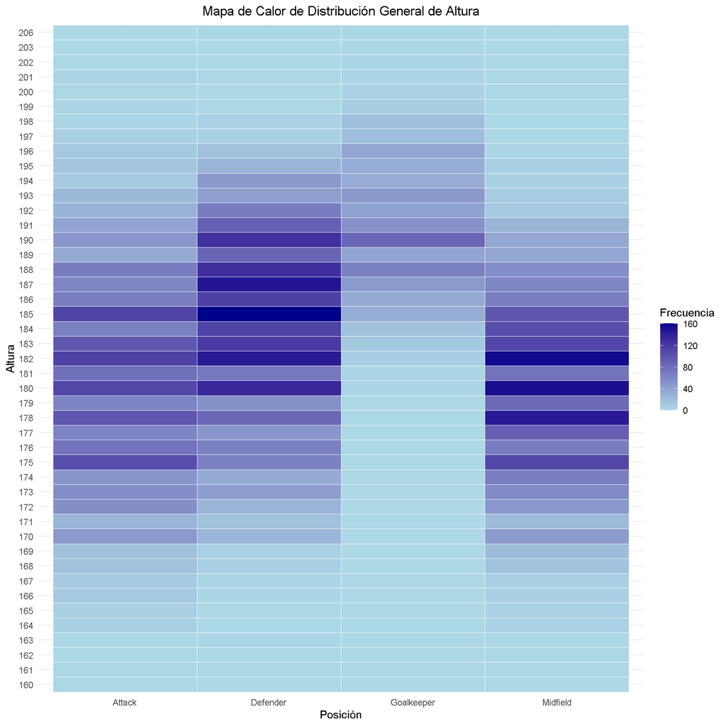

```r
library(ggplot2)
library(reshape2)

freq_table <- table(Altura, position)

freq_df <- as.data.frame(as.table(freq_table))

ggplot(freq_df, aes(x = position, y = Altura, fill = Freq)) +
  geom_tile(color = "white") +
  scale_fill_gradient(low = "lightblue", high = "darkblue") +
  labs(title = "Mapa de Calor de Distribución General de Altura",
       x = "Posición",
       y = "Altura",
       fill = "Frecuencia") +
  theme_minimal() +
  theme(
    plot.title = element_text(color = "black", hjust = 0.5)
  )
```

Ahora vamos a representar para cada posicion, la frecuencia de altura y visualmente vemos con un degradado de color donde se situan las diferentes alturas por posición.

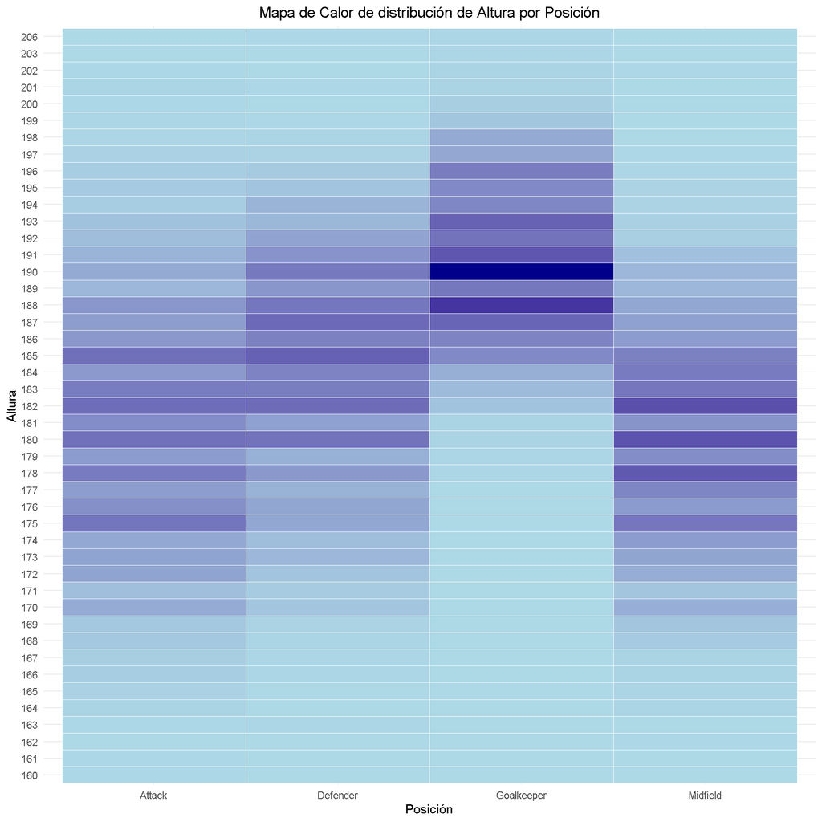

```r
freq_table <- table(Altura, position)

prop_table <- prop.table(freq_table, margin = 2) * 100

prop_df <- as.data.frame(as.table(prop_table))

colnames(prop_df) <- c("Altura", "Posicion", "Porcentaje")


ggplot(prop_df, aes(x = Posicion, y = Altura, fill = Porcentaje)) +
  geom_tile(color = "white") +
  scale_fill_gradient(low = "lightblue", high = "darkblue",guide = "none") +
  labs(title = "Mapa de Calor de distribución de Altura por Posición",
       x = "Posición",
       y = "Altura",
       fill = "Porcentaje") +
  theme_minimal() +
  theme(
    plot.title = element_text(color = "black", hjust = 0.5)
  )
```

Por ejemplo, podemos observar a simple vista que los porteros tienen una mayor concentración de alturas en 190 cm.

### Gráfico combinado

Ahora representaremos un **gráfico combinado**; su propósito es obtener la mayor cantidad de información visualmente, ya que combina la densidad, el diagrama de cajas y el grafico de dispersión, además de observarse claramente los valores atípicos, los cuartiles Q1 y Q3 y la mediana de los datos; en el script se enumera los pasos a seguir para obtener el resultado.

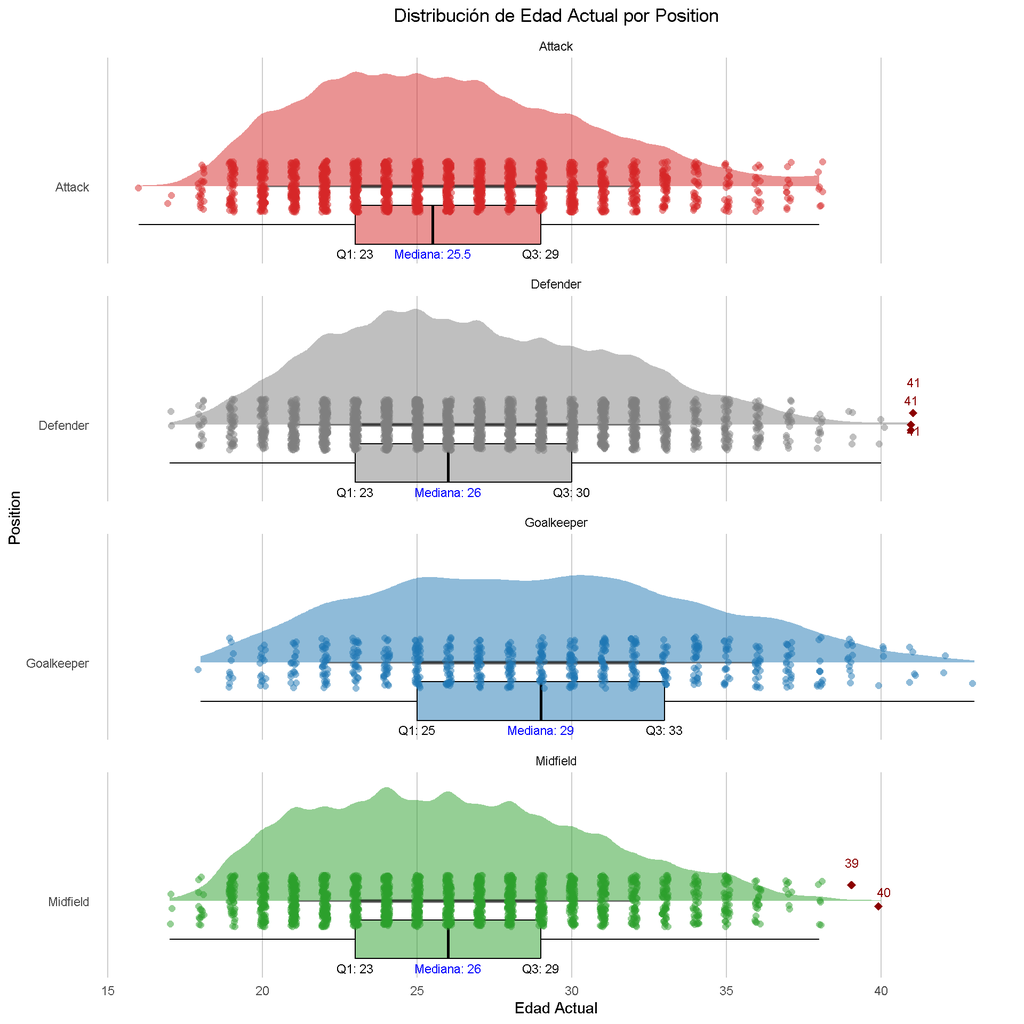

```r
library(tidyverse)
library(ggdist)

# a) Calculamos las estadísticas del diagrama de cajas para cada grupo de ´position':

boxplot_stats <- df %>%
  group_by(position) %>%
  summarise(
    ymin = min(edad_actual),
    ymax = max(edad_actual),
    q1 = quantile(edad_actual, 0.25),
    q3 = quantile(edad_actual, 0.75),
    lower_whisker = q1 - 1.5 * (q3 - q1),
    upper_whisker = q3 + 1.5 * (q3 - q1),
    median = median(edad_actual),
    .groups = 'drop'
  )

# b) Identificamos los valores atípicos:

df <- df %>%
  group_by(position) %>%
  mutate(
    is_outlier = ifelse(edad_actual %in% boxplot.stats(edad_actual)$out, "Outlier", "Normal")
  )

# c) Creamos el gráfico combinado:

ggplot(df, aes(x = edad_actual, y = position)) +

  # 1- Creamos el gráfico de densidad:

  stat_halfeye(
    aes(fill = position),
    adjust = 0.5,
    width = 0.5,
    .width = c(0.5, 0.8),
    point_colour = NA,
    alpha = 0.5
  ) +

  # 2- Creamos el diagrama de cajas:

  geom_boxplot(
    aes(y = position, fill = position),
    width = 0.3,
    outlier.shape = NA,
    alpha = 0.5,
    color = "black",
    position = position_nudge(y = -0.3)
  ) +

  # 3- Creamos las etiquetas para cuartiles y mediana:

  geom_text(
    data = boxplot_stats,
    aes(x = q1, y = position, label = paste("Q1:", round(q1, 1))),
    vjust = 7.5,
    size = 3,
    color = "black"
  ) +
  geom_text(
    data = boxplot_stats,
    aes(x = q3, y = position, label = paste("Q3:", round(q3, 1))),
    vjust = 7.5,
    size = 3,
    color = "black"
  ) +
  geom_text(
    data = boxplot_stats,
    aes(x = median, y = position, label = paste("Mediana:", round(median, 1))),
    vjust = 7.5,
    size = 3,
    color = "blue"
  ) +

  # 4- Creamos los puntos dispersos, los cuales se distribuyen uniformemente dentro del diagrama de cajas y excluimos los valores atípicos:

  geom_point(
    aes(x = edad_actual, color = position, shape = is_outlier),
    size = 2,
    alpha = 0.5,
    position = position_jitter(
      width = 0.1,
      height = 0.2
    ),
    data = df %>% filter(is_outlier == "Normal")
  ) +

  # 5- Creamos los puntos rojos para identificar los valores atípicos:

  geom_point(
    data = df %>% filter(is_outlier == "Outlier"),
    aes(x = edad_actual, y = position),
    color = "darkred",
    shape = 18,
    size = 2.5,
    position = position_jitter(
      width = 0.1,
      height = 0.2
    )
  ) +

  # 6- Creamos las etiquetas para los valores atípicos:

  geom_text(
    data = df %>% filter(is_outlier == "Outlier"),
    aes(x = edad_actual, y = position, label = round(edad_actual, 1)),
    vjust = -1.5,                   # Ajusta la posición vertical de la etiqueta
    size = 3,                       # Tamaño del texto
    color = "darkred",
    position = position_jitter(
      width = 0.1,
      height = 0.2
    )
  ) +

  # 7- Añadimos personalización adicional, en la que aplicamos degradación de color en los gráficos para que visualmente se aprecien mejor los resultados:

  theme_minimal() +
  labs(
    title = "Distribución de Edad Actual por Position",
    x = "Edad Actual",
    y = "Position"
  ) +
  theme(
    legend.position = "none",
    panel.grid.major.y = element_blank(),
    panel.grid.minor.y = element_blank(),
    panel.grid.major.x = element_line(color = "gray80"),
    panel.grid.minor.x = element_blank(),
    plot.title = element_text(hjust = 0.5)
  ) +
  facet_wrap(~ position, scales = "free_y", ncol = 1) +
  scale_fill_manual(values = c(
    "Goalkeeper" = "#1f77b4",
    "Defense" = "#ff7f0e",
    "Midfield" = "#2ca02c",
    "Attack" = "#d62728")) +
  scale_color_manual(values = c(
    "Goalkeeper" = "#1f77b4",
    "Defense" = "#ff7f0e",
    "Midfield" = "#2ca02c",
    "Attack" = "#d62728")) +
  scale_shape_manual(values = c("Normal" = 16, "Outlier" = 16))
```

### Treemap (mapa de árbol)

Ahora visualizamos un mapa de árbol (Treemap) para observar la distribución del pie_bueno del jugador con relación a la posición que ocupa.

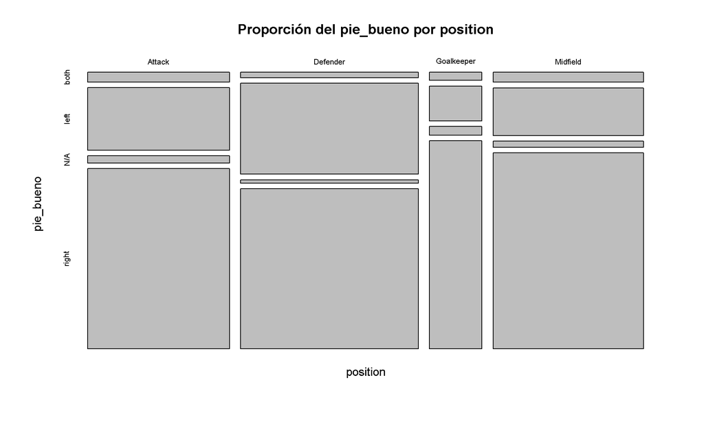

### Gráfico de dispersión

Vamos a visualizar un gráfico de dispersión en el que tomamos como variable de entrada o independiente a ‘minutos_jugados’ y como variable de respuesta o dependiente a ‘tarjetas_amarillas’; además vamos a obtener la correlación de Pearson.

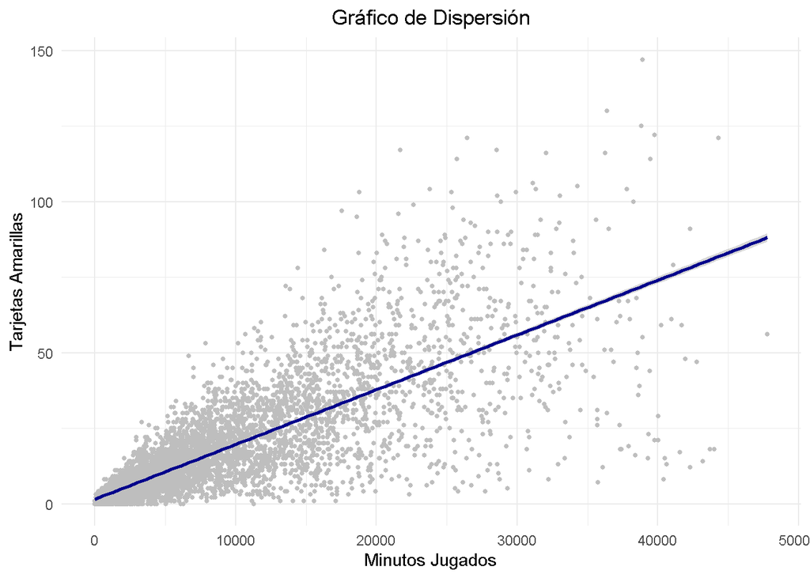

```r
ggplot(df, aes(x = minutos_jugados, y = tarjetas_amarillas)) +
  geom_point(color = "grey", size = 1) +
  labs(
    title = "Gráfico de Dispersión",
    x = "Minutos Jugados",
    y = "Tarjetas Amarillas"
  ) +
  theme_minimal() +
  theme(
    plot.title = element_text(hjust = 0.5)
  ) +
  geom_smooth(method = "lm", color = "darkblue")
```

Calculamos la correlación entre las dos variables:

```r
cor_test <- cor.test(minutos_jugados, tarjetas_amarillas)
correlation <- cor_test$estimate

print(paste("Correlación entre minutos jugados y tarjetas amarillas:", round(correlation, 2)))
```

```
## [1] "Correlación entre minutos jugados y tarjetas amarillas: 0.8"
```

Creamos un modelo de regresión lineal para ver la significancia del modelo:

```r
modelo <- lm(tarjetas_amarillas ~ minutos_jugados, data = df)
```

Resumimos el resultado del modelo:

```
##
## Call:
## lm(formula = tarjetas_amarillas ~ minutos_jugados, data = df)
##
## Residuals:
##     Min      1Q  Median      3Q     Max
## -66.765  -3.293  -1.189   2.970  76.128
##
## Coefficients:
##                  Estimate Std. Error t value Pr(>|t|)
## (Intercept)     1.548e+00  1.899e-01   8.149 4.38e-16 ***
## minutos_jugados 1.812e-03  1.687e-05 107.414  < 2e-16 ***
## ---
## Signif. codes:  0 '***' 0.001 '**' 0.01 '*' 0.05 '.' 0.1 ' ' 1
##
## Residual standard error: 10.95 on 6284 degrees of freedom
## Multiple R-squared:  0.6474, Adjusted R-squared:  0.6473
## F-statistic: 1.154e+04 on 1 and 6284 DF,  p-value: < 2.2e-16
```

A simple vista se puede observar que existe una fuerte correlación entre las dos variables, refutado por el valor de la correlación de **0,80** que indica una **correlación fuerte y positiva,** es decir, que a más minutos jugados, más números de tarjetas amarillas recibe.

Además, la variable ‘minutos_jugados’ **es significativa**s con respecto al resultado y el coeficiente Multiple de R-squared nos indica que la variable ‘minutos_jugados’ explica el 64,74 % de la variable ‘tarjetas_amarillas’, aunque existan otros factores que expliquen el 35,26 % de la variable ‘tarjetas_amarillas’.

## ANALISIS DE MULTIVARIABLES

### Gráfico multivariable

Ahora vamos a realizar un análisis multivariable entre las variables numéricas, agrupadas por la variable categórica ‘position’ del conjunto de datos:

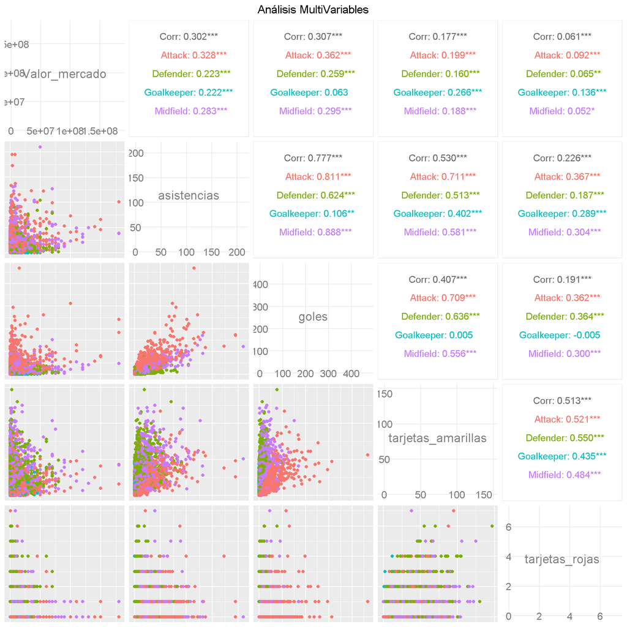

```r
library(GGally)
library(ggplot2)

df_subset <- df[1:6286, ]

ggpairs(df_subset[, c("Valor_mercado", "asistencias", "goles","tarjetas_amarillas","tarjetas_rojas")],
        axisLabels = "internal",
        aes(color = position),
        title = "Análisis MultiVariables") +
        theme(plot.title = element_text(hjust = 0.5))
```

En éste gráfico multivariable podemos extraer multitud de conclusiones, ya que las posiciones (variable categórica) están definidas por colores y vemos con total claridad las correlaciones entre las variables numéricas de todo el conjunto de datos.

Para ver la significancia de los resultados obtenidos vamos a realizar una prueba de hipótesis con el siguiente planteamiento:

Hipótesis nula (H0): No hay correlación en el conjunto de datos.

Hipótesis alternativa (H1): Existe correlación en el conjunto de datos.

Para ello usamos la corrección de Bonferroni para comparaciones múltiples, detallado en los siguientes pasos:

```r
# a) Calcular la matriz de correlaciones:

correlation_matrix <- cor(df_subset[, c("Valor_mercado", "asistencias", "goles", "tarjetas_amarillas", "tarjetas_rojas")], use = "complete.obs")

# b) Realizamos la función para calcular valores p de la correlación:
get_p_value <- function(x, y) {
  cor.test(x, y)$p.value
}

# c) Creamos una matriz de valores p:

p_values <- matrix(nrow = ncol(df_subset[, c("Valor_mercado", "asistencias", "goles", "tarjetas_amarillas", "tarjetas_rojas")]),
                   ncol = ncol(df_subset[, c("Valor_mercado", "asistencias", "goles", "tarjetas_amarillas", "tarjetas_rojas")]))
colnames(p_values) <- colnames(correlation_matrix)
rownames(p_values) <- colnames(correlation_matrix)

for(i in 1:ncol(p_values)) {
  for(j in 1:ncol(p_values)) {
    if (i != j) {
      p_values[i, j] <- get_p_value(df_subset[[colnames(p_values)[i]]], df_subset[[colnames(p_values)[j]]])
    } else {
      p_values[i, j] <- NA
    }
  }
}

# d) Mostramos la matriz de correlaciones y los valores p:

print("Matriz de Correlaciones:")
```

```
## [1] "Matriz de Correlaciones:"
```

```r
print(correlation_matrix)
```

```
##                    Valor_mercado asistencias     goles tarjetas_amarillas
## Valor_mercado         1.00000000   0.3016228 0.3068244          0.1771735
## asistencias           0.30162277   1.0000000 0.7768036          0.5300208
## goles                 0.30682439   0.7768036 1.0000000          0.4074856
## tarjetas_amarillas    0.17717347   0.5300208 0.4074856          1.0000000
## tarjetas_rojas        0.06145973   0.2256178 0.1911881          0.5126801
##                    tarjetas_rojas
## Valor_mercado          0.06145973
## asistencias            0.22561784
## goles                  0.19118814
## tarjetas_amarillas     0.51268011
## tarjetas_rojas         1.00000000
```

```r
print("Matriz de Valores p:")
```

```
## [1] "Matriz de Valores p:"
```

```r
print(p_values)
```

```
##                    Valor_mercado   asistencias         goles tarjetas_amarillas
## Valor_mercado                 NA 2.322529e-132 3.975198e-137       1.704813e-45
## asistencias        2.322529e-132            NA  0.000000e+00       0.000000e+00
## goles              3.975198e-137  0.000000e+00            NA      4.200099e-250
## tarjetas_amarillas  1.704813e-45  0.000000e+00 4.200099e-250                 NA
## tarjetas_rojas      1.080215e-06  2.277570e-73  8.067037e-53       0.000000e+00
##                    tarjetas_rojas
## Valor_mercado        1.080215e-06
## asistencias          2.277570e-73
## goles                8.067037e-53
## tarjetas_amarillas   0.000000e+00
## tarjetas_rojas                 NA
```

```r
# e) Aplicamos la corrección de Bonferroni:

p_values_flat <- as.vector(p_values[!is.na(p_values)])
adjusted_p_values <- p.adjust(p_values_flat, method = "bonferroni")

# f) Creamos una matriz de valores p ajustados:

adjusted_p_matrix <- matrix(NA, nrow = nrow(p_values), ncol = ncol(p_values))
colnames(adjusted_p_matrix) <- colnames(p_values)
rownames(adjusted_p_matrix) <- rownames(p_values)

# g) Rellenamos la matriz con los valores p ajustados:

k <- 1
for(i in 1:nrow(adjusted_p_matrix)) {
  for(j in 1:ncol(adjusted_p_matrix)) {
    if (i != j) {
      adjusted_p_matrix[i, j] <- adjusted_p_values[k]
      k <- k + 1
    }
  }
}

# h) Mostramos la matriz de valores p ajustados:

print("Matriz de Valores p Ajustados (Bonferroni):")
```

```
## [1] "Matriz de Valores p Ajustados (Bonferroni):"
```

```r
print(adjusted_p_matrix)
```

```
##                    Valor_mercado   asistencias         goles tarjetas_amarillas
## Valor_mercado                 NA 4.645059e-131 7.950396e-136       3.409625e-44
## asistencias        4.645059e-131            NA  0.000000e+00       0.000000e+00
## goles              7.950396e-136  0.000000e+00            NA      8.400199e-249
## tarjetas_amarillas  3.409625e-44  0.000000e+00 8.400199e-249                 NA
## tarjetas_rojas      2.160430e-05  4.555140e-72  1.613407e-51       0.000000e+00
##                    tarjetas_rojas
## Valor_mercado        2.160430e-05
## asistencias          4.555140e-72
## goles                1.613407e-51
## tarjetas_amarillas   0.000000e+00
## tarjetas_rojas                 NA
```

Todo los p-valores ajustados son extremadamente pequeños, eso significa que **se rechaza la hipótesis nula y se acepta la hipótesis alternativa,** es decir, que estadísticamente se prueba que **existe correlación entre las variables**, en mayor o menor grado.